# p8105_Linear_Models

Felix Tran

November 8, 2018

# Airbnb example

```r
data("nyc_airbnb")

nyc_airbnb =
  nyc_airbnb %>%
  mutate(stars = review_scores_location / 2) %>%
  rename(boro = neighbourhood_group,
         neighborhood = neighbourhood) %>%
  filter(boro != "Staten Island") %>%
  select(price, stars, boro, neighborhood, room_type)
```

### Fit a linear model of price on rating and borough

```r
fit = lm(price ~ stars + boro, data = nyc_airbnb)
```

### Look at summary of the lm output

The lm output is very hard to work with. You can manipulate output using summary() but it’s annoying.

```r
summary(fit)
```

```
##
## Call:
## lm(formula = price ~ stars + boro, data = nyc_airbnb)
##
## Residuals:
##    Min     1Q Median     3Q    Max
## -169.8  -64.0  -29.0   20.2 9870.0
##
## Coefficients:
##               Estimate Std. Error t value Pr(>|t|)
## (Intercept)    -70.414     14.021  -5.022 5.14e-07 ***
## stars           31.990      2.527  12.657  < 2e-16 ***
## boroBrooklyn    40.500      8.559   4.732 2.23e-06 ***
## boroManhattan   90.254      8.567  10.534  < 2e-16 ***
## boroQueens      13.206      9.065   1.457    0.145
## ---
## Signif. codes:  0 '***' 0.001 '**' 0.01 '*' 0.05 '.' 0.1 ' ' 1
##
## Residual standard error: 181.5 on 30525 degrees of freedom
##   (9962 observations deleted due to missingness)
## Multiple R-squared:  0.03423,    Adjusted R-squared:  0.03411
## F-statistic: 270.5 on 4 and 30525 DF,  p-value: < 2.2e-16
```

### Broom package makes life easier

glance() extracts the summary stats of lm(). tidy() extracts the coefficients, test stats of lm() model. The tidied output is easier to manipulate for more analyses or for displaying results.

```r
fit %>%
  broom::glance()
```

```
## # A tibble: 1 x 11
##   r.squared adj.r.squared sigma statistic   p.value    df  logLik    AIC
## *     <dbl>         <dbl> <dbl>     <dbl>     <dbl> <int>   <dbl>  <dbl>
## 1    0.0342        0.0341  182.      271. 6.73e-229     5 -2.02e5 4.04e5
## # ... with 3 more variables: BIC <dbl>, deviance <dbl>, df.residual <int>
```

```r
fit %>%
  broom::tidy() %>%
  select(term, estimate, p.value) %>%
  mutate(term = str_replace(term, "boro", "Boro: ")) %>%
  knitr::kable(digits = 3)
```

| term | estimate | p.value |
| --- | --- | --- |
| (Intercept) | -70.414 | 0.000 |
| stars | 31.990 | 0.000 |
| Boro: Brooklyn | 40.500 | 0.000 |
| Boro: Manhattan | 90.254 | 0.000 |
| Boro: Queens | 13.206 | 0.145 |

### Can specify factor levels to set the reference group yourself

lm() transforms the boro variable into a factor using the first value alphabetically (Bronx) as the reference group). fct_infreq() sets the factor levels with the most frequent value as the reference group.

Changing the reference group/re-leveling does not change the overall fit of the model.

```r
nyc_airbnb =
  nyc_airbnb %>%
  mutate(boro = fct_infreq(boro),
         room_type = fct_infreq(room_type))

fit = lm(price ~ stars + boro, data = nyc_airbnb)
fit %>%
  broom::tidy() %>%
  select(term, estimate, p.value) %>%
  mutate(term = str_replace(term, "boro", "Boro: ")) %>%
  knitr::kable(digits = 3)
```

| term | estimate | p.value |
| --- | --- | --- |
| (Intercept) | 19.839 | 0.104 |
| stars | 31.990 | 0.000 |
| Boro: Brooklyn | -49.754 | 0.000 |
| Boro: Queens | -77.048 | 0.000 |
| Boro: Bronx | -90.254 | 0.000 |

# Diagnostics

add_residuals() from the modelr package gives you the residuals from a tidied, fitted model for every observation. The output is the the same dataset you put into it with an added column for the residuals.

```r
modelr::add_residuals(nyc_airbnb, fit)
```

```
## # A tibble: 40,492 x 6
##    price stars boro  neighborhood room_type        resid
##    <int> <dbl> <fct> <chr>        <fct>            <dbl>
##  1    99   5   Bronx City Island  Private room      9.47
##  2   200  NA   Bronx City Island  Private room     NA
##  3   300  NA   Bronx City Island  Entire home/apt  NA
##  4   125   5   Bronx City Island  Entire home/apt  35.5
##  5    69   5   Bronx City Island  Private room    -20.5
##  6   125   5   Bronx City Island  Entire home/apt  35.5
##  7    85   5   Bronx City Island  Entire home/apt  -4.53
##  8    39   4.5 Bronx Allerton     Private room    -34.5
##  9    95   5   Bronx Allerton     Entire home/apt   5.47
## 10   125   4.5 Bronx Allerton     Entire home/apt  51.5
## # ... with 40,482 more rows
```

You can plot the residuals or run tests on them to assess the fit of your model.

add_predictions() from modelr package is the same as add_residuals() except it gives you the predicted y values based on the model for each observation.

```r
modelr::add_predictions(nyc_airbnb, fit)
```

```
## # A tibble: 40,492 x 6
##    price stars boro  neighborhood room_type        pred
##    <int> <dbl> <fct> <chr>        <fct>           <dbl>
##  1    99   5   Bronx City Island  Private room     89.5
##  2   200  NA   Bronx City Island  Private room     NA
##  3   300  NA   Bronx City Island  Entire home/apt  NA
##  4   125   5   Bronx City Island  Entire home/apt  89.5
##  5    69   5   Bronx City Island  Private room     89.5
##  6   125   5   Bronx City Island  Entire home/apt  89.5
##  7    85   5   Bronx City Island  Entire home/apt  89.5
##  8    39   4.5 Bronx Allerton     Private room     73.5
##  9    95   5   Bronx Allerton     Entire home/apt  89.5
## 10   125   4.5 Bronx Allerton     Entire home/apt  73.5
## # ... with 40,482 more rows
```

# Hypothesis testing

Just use tidy() to get the p-values.

```r
fit %>%
  broom::tidy()
```

```
## # A tibble: 5 x 5
##   term         estimate std.error statistic   p.value
##   <chr>           <dbl>     <dbl>     <dbl>     <dbl>
## 1 (Intercept)      19.8     12.2       1.63 1.04e-  1
## 2 stars            32.0      2.53     12.7  1.27e- 36
## 3 boroBrooklyn    -49.8      2.23    -22.3  6.32e-109
## 4 boroQueens      -77.0      3.73    -20.7  2.58e- 94
## 5 boroBronx       -90.3      8.57    -10.5  6.64e- 26
```

Compare nested models. We can test and see if adding room type to the model is better than the null model. anova() can only be used to test nested models.

```r
fit_null = lm(price ~ stars + boro, data = nyc_airbnb)
fit_alt = lm(price ~ stars + boro + room_type, data = nyc_airbnb)

anova(fit_null, fit_alt) %>%
  broom::tidy()
```

```
## # A tibble: 2 x 6
##   res.df         rss    df     sumsq statistic p.value
## *  <dbl>       <dbl> <dbl>     <dbl>     <dbl>   <dbl>
## 1  30525 1005601724.    NA       NA        NA       NA
## 2  30523  921447496.     2 84154228.     1394.       0
```

Based on this ANOVA, we can say the alt model with room_type is different from the null model and better.

# Nesting data

```r
nyc_airbnb %>%
  lm(price ~ stars * boro + room_type * boro, data = .) %>%
  broom::tidy() %>%
  knitr::kable(digits = 3)
```

| term | estimate | std.error | statistic | p.value |
| --- | --- | --- | --- | --- |
| (Intercept) | 95.694 | 19.184 | 4.988 | 0.000 |
| stars | 27.110 | 3.965 | 6.838 | 0.000 |
| boroBrooklyn | -26.066 | 25.080 | -1.039 | 0.299 |
| boroQueens | -4.118 | 40.674 | -0.101 | 0.919 |
| boroBronx | -5.627 | 77.808 | -0.072 | 0.942 |
| room_typePrivate room | -124.188 | 2.996 | -41.457 | 0.000 |
| room_typeShared room | -153.635 | 8.692 | -17.676 | 0.000 |
| stars:boroBrooklyn | -6.139 | 5.237 | -1.172 | 0.241 |
| stars:boroQueens | -17.455 | 8.539 | -2.044 | 0.041 |
| stars:boroBronx | -22.664 | 17.099 | -1.325 | 0.185 |
| boroBrooklyn:room_typePrivate room | 31.965 | 4.328 | 7.386 | 0.000 |
| boroQueens:room_typePrivate room | 54.933 | 7.459 | 7.365 | 0.000 |
| boroBronx:room_typePrivate room | 71.273 | 18.002 | 3.959 | 0.000 |
| boroBrooklyn:room_typeShared room | 47.797 | 13.895 | 3.440 | 0.001 |
| boroQueens:room_typeShared room | 58.662 | 17.897 | 3.278 | 0.001 |
| boroBronx:room_typeShared room | 83.089 | 42.451 | 1.957 | 0.050 |

```r
nest_lm_res =
  nyc_airbnb %>%
  group_by(boro) %>%
  nest() %>%
  mutate(models = map(data, ~lm(price ~ stars + room_type, data = .x)),
         models = map(models, broom::tidy)) %>%
  select(-data) %>%
  unnest()
```

### Crazier example

```r
manhattan_airbnb =
  nyc_airbnb %>%
  filter(boro == "Manhattan")

manhattan_nest_lm_res =
  manhattan_airbnb %>%
  group_by(neighborhood) %>%
  nest() %>%
  mutate(models = map(data, ~lm(price ~ stars + room_type, data = .x)),
         models = map(models, broom::tidy)) %>%
  select(-data) %>%
  unnest()
```

Can show average difference in price from whole apartment/home for each neighborhood by room type. A shared room appears to save you a little more money vs. a whole apartment compared to a private room vs. whole apartment.

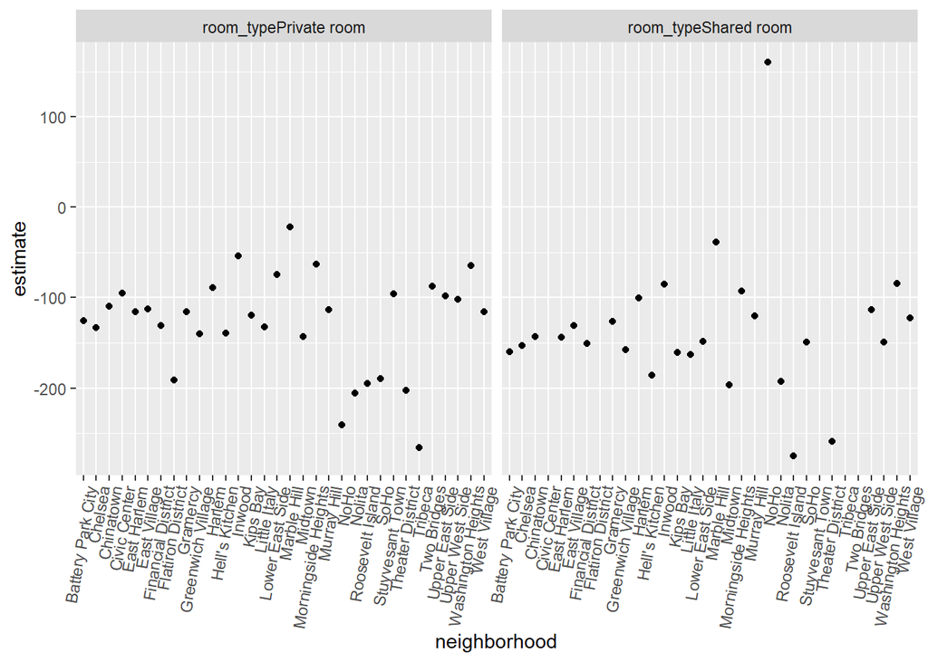

```r
manhattan_nest_lm_res %>%
  filter(str_detect(term, "room_type")) %>%
  ggplot(aes(x = neighborhood, y = estimate)) +
  geom_point() +
  facet_wrap(~term) +
  theme(axis.text.x = element_text(angle = 80, hjust = 1))
```

# Binary outcomes

```r
data_url <- RCurl::getURL('https://raw.githubusercontent.com/washingtonpost/data-homicides/master/homicide-data.csv')

baltimore_df =
  readr::read_csv(data_url) %>%
  filter(city == "Baltimore") %>%
  mutate(resolved = as.numeric(disposition == "Closed by arrest"),
         victim_age = as.numeric(victim_age),
         victim_race = fct_relevel(victim_race, "White")) %>%
  select(resolved, victim_age, victim_race, victim_sex)

glm(resolved ~ victim_age + victim_race, data = baltimore_df,
    family = binomial())
```

```
##
## Call:  glm(formula = resolved ~ victim_age + victim_race, family = binomial(),
##     data = baltimore_df)
##
## Coefficients:
##         (Intercept)           victim_age     victim_raceAsian
##            0.535470            -0.006147             0.242438
##    victim_raceBlack  victim_raceHispanic     victim_raceOther
##           -1.026360            -0.449746            -1.028579
##
## Degrees of Freedom: 2826 Total (i.e. Null);  2821 Residual
## Null Deviance:       3676
## Residual Deviance: 3631  AIC: 3643
```

Can tidy logistic regression model output

```r
fit_logistic <- glm(resolved ~ victim_age + victim_race, data = baltimore_df,
    family = binomial())

fit_logistic %>%
  broom::tidy() %>%
  mutate(OR = boot::inv.logit(estimate))
```

```
## # A tibble: 6 x 6
##   term                estimate std.error statistic       p.value    OR
##   <chr>                  <dbl>     <dbl>     <dbl>         <dbl> <dbl>
## 1 (Intercept)          0.535     0.206       2.60  0.00935       0.631
## 2 victim_age          -0.00615   0.00326    -1.89  0.0593        0.498
## 3 victim_raceAsian     0.242     0.648       0.374 0.708         0.560
## 4 victim_raceBlack    -1.03      0.170      -6.05  0.00000000145 0.264
## 5 victim_raceHispanic -0.450     0.312      -1.44  0.149         0.389
## 6 victim_raceOther    -1.03      0.882      -1.17  0.243         0.263
```

Some exploratory graphing suggests that age doesn’t have a continuous, linear effect on whether or not the homicide is resolved.

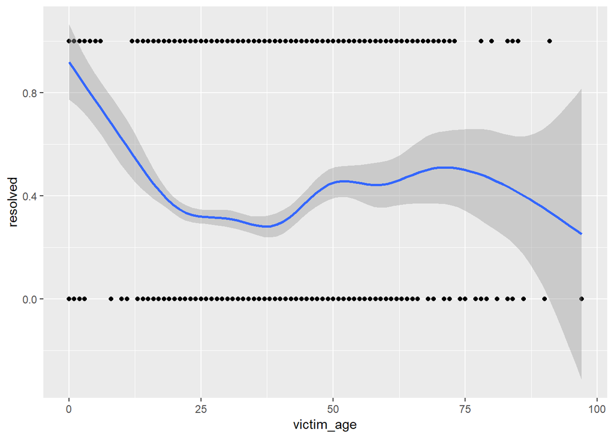

```r
baltimore_df %>%
  ggplot(aes(x = victim_age, y = resolved)) + geom_point() + geom_smooth()
```